## Clustering

Libraries

Basic data that we generate as an example (modification of code borrowed from https://www.tidymodels.org/learn/statistics/k-means/)

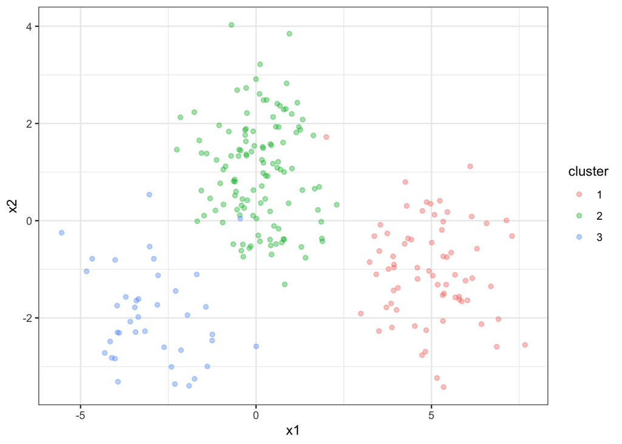

```r
set.seed(27)
centers = tibble(
  cluster = factor(1:3), #three clusters
  num_points = c(70, 120, 40),  # number of points in each cluster
  x1 = c(5, 0, -3),              # x1 coordinate of cluster centers
  x2 = c(-1, 1, -2)              # x2 coordinate of cluster centers
)

labelled_points =
  centers %>%
  mutate(
    x1 = map2(num_points, x1, rnorm), #randomly generate points for each cluster for x1
    x2 = map2(num_points, x2, rnorm)  #randomly generate points for each cluster for x2
  ) %>%
  select(-num_points) %>%
  unnest(cols = c(x1, x2))

ggplot(labelled_points, aes(x1, x2, color = cluster)) +
  geom_point(alpha = 0.4) + theme_bw()
```

```r
points = labelled_points %>% select(-cluster) #get rid of the cluster column

set.seed(123)
kclust = kmeans(points, centers = 3) #run k-means clustering with k = 3
kclust #view results
```

```
## K-means clustering with 3 clusters of sizes 122, 39, 69
##
## Cluster means:
##            x1        x2
## 1  0.09141923  1.005151
## 2 -3.02082282 -1.979361
## 3  5.01952714 -1.060719
##
## Clustering vector:
##   [1] 3 3 3 3 3 3 3 3 3 3 3 3 3 3 3 3 3 3 3 3 3 3 3 3 1 3 3 3 3 3 3 3 3 3 3 3 3
##  [38] 3 3 3 3 3 3 3 3 3 3 3 3 3 3 3 3 3 3 3 3 3 3 3 3 3 3 3 3 3 3 3 3 3 1 1 1 1
##  [75] 1 1 1 1 1 1 1 1 1 1 1 1 1 1 1 1 1 1 1 1 1 1 1 1 1 1 1 1 1 1 1 1 1 1 1 1 1
## [112] 1 1 1 1 1 1 1 1 1 1 1 1 1 1 1 1 1 1 1 1 1 1 1 1 1 1 1 1 1 1 1 1 1 1 1 1 1
## [149] 1 1 1 1 1 1 1 1 1 1 1 1 1 1 1 1 1 1 1 1 1 1 1 1 1 1 1 1 1 1 1 1 1 1 1 1 1
## [186] 1 1 1 1 1 2 2 2 2 2 2 2 2 1 2 2 2 2 2 2 2 2 2 2 2 2 2 2 2 2 2 2 2 2 2 2 2
## [223] 2 2 2 2 2 2 2 2
##
## Within cluster sum of squares by cluster:
## [1] 243.07711  84.80042 144.61358
##  (between_SS / total_SS =  82.3 %)
##
## Available components:
##
## [1] "cluster"      "centers"      "totss"        "withinss"     "tot.withinss"
## [6] "betweenss"    "size"         "iter"         "ifault"
```

Add the cluster assignment to the dataset

```r
points = augment(kclust, points)
points
```

```
## # A tibble: 230 × 3
##       x1       x2 .cluster
##    <dbl>    <dbl> <fct>
##  1  6.91 -2.03    3
##  2  6.14  0.0868  3
##  3  4.24 -0.476   3
##  4  3.54 -0.0833  3
##  5  3.91 -0.735   3
##  6  5.30 -0.190   3
##  7  5.01 -0.452   3
##  8  6.16 -1.18    3
##  9  7.13  0.00640 3
## 10  5.24  0.410   3
## # ℹ 220 more rows
```

Plot the clusters

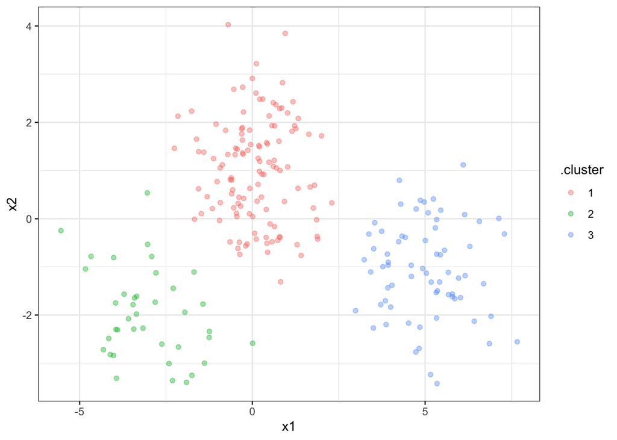

```r
ggplot(points, aes(x1, x2, color = .cluster)) +
  geom_point(alpha = 0.4) + theme_bw()
```

Read in data for a more practical example

```r
customers = read_csv("CustomerData.csv")
str(customers)
```

```
## spc_tbl_ [440 × 8] (S3: spec_tbl_df/tbl_df/tbl/data.frame)
##  $ Channel         : num [1:440] 2 2 2 1 2 2 2 2 1 2 ...
##  $ Region          : num [1:440] 3 3 3 3 3 3 3 3 3 3 ...
##  $ Fresh           : num [1:440] 12669 7057 6353 13265 22615 ...
##  $ Dairy           : num [1:440] 9656 9810 8808 1196 5410 ...
##  $ Grocery         : num [1:440] 7561 9568 7684 4221 7198 ...
##  $ Frozen          : num [1:440] 214 1762 2405 6404 3915 ...
##  $ Detergents_Paper: num [1:440] 2674 3293 3516 507 1777 ...
##  $ Deli            : num [1:440] 1338 1776 7844 1788 5185 ...
##  - attr(*, "spec")=
##   .. cols(
##   ..   Channel = col_double(),
##   ..   Region = col_double(),
##   ..   Fresh = col_double(),
##   ..   Dairy = col_double(),
##   ..   Grocery = col_double(),
##   ..   Frozen = col_double(),
##   ..   Detergents_Paper = col_double(),
##   ..   Deli = col_double()
##   .. )
##  - attr(*, "problems")=<externalptr>
```

```r
summary(customers)
```

```
##     Channel          Region          Fresh            Dairy
##  Min.   :1.000   Min.   :1.000   Min.   :     3   Min.   :   55
##  1st Qu.:1.000   1st Qu.:2.000   1st Qu.:  3128   1st Qu.: 1533
##  Median :1.000   Median :3.000   Median :  8504   Median : 3627
##  Mean   :1.323   Mean   :2.543   Mean   : 12000   Mean   : 5796
##  3rd Qu.:2.000   3rd Qu.:3.000   3rd Qu.: 16934   3rd Qu.: 7190
##  Max.   :2.000   Max.   :3.000   Max.   :112151   Max.   :73498
##     Grocery          Frozen        Detergents_Paper       Deli
##  Min.   :    3   Min.   :   25.0   Min.   :    3.0   Min.   :    3.0
##  1st Qu.: 2153   1st Qu.:  742.2   1st Qu.:  256.8   1st Qu.:  408.2
##  Median : 4756   Median : 1526.0   Median :  816.5   Median :  965.5
##  Mean   : 7951   Mean   : 3071.9   Mean   : 2881.5   Mean   : 1524.9
##  3rd Qu.:10656   3rd Qu.: 3554.2   3rd Qu.: 3922.0   3rd Qu.: 1820.2
##  Max.   :92780   Max.   :60869.0   Max.   :40827.0   Max.   :47943.0
```

Preparing the data. Remove missingness (there is none in this data) or impute missing values.

We also scale the data. This is critical for quantitative data to ensure that no variable (particularly a variable with large values, skews the data and the resulting clusters).

```r
customers_scaled = scale(customers)
summary(customers_scaled)
```

```
##     Channel            Region            Fresh             Dairy
##  Min.   :-0.6895   Min.   :-1.9931   Min.   :-0.9486   Min.   :-0.7779
##  1st Qu.:-0.6895   1st Qu.:-0.7015   1st Qu.:-0.7015   1st Qu.:-0.5776
##  Median :-0.6895   Median : 0.5900   Median :-0.2764   Median :-0.2939
##  Mean   : 0.0000   Mean   : 0.0000   Mean   : 0.0000   Mean   : 0.0000
##  3rd Qu.: 1.4470   3rd Qu.: 0.5900   3rd Qu.: 0.3901   3rd Qu.: 0.1889
##  Max.   : 1.4470   Max.   : 0.5900   Max.   : 7.9187   Max.   : 9.1732
##     Grocery            Frozen         Detergents_Paper       Deli
##  Min.   :-0.8364   Min.   :-0.62763   Min.   :-0.6037   Min.   :-0.5397
##  1st Qu.:-0.6101   1st Qu.:-0.47988   1st Qu.:-0.5505   1st Qu.:-0.3959
##  Median :-0.3363   Median :-0.31844   Median :-0.4331   Median :-0.1984
##  Mean   : 0.0000   Mean   : 0.00000   Mean   : 0.0000   Mean   : 0.0000
##  3rd Qu.: 0.2846   3rd Qu.: 0.09935   3rd Qu.: 0.2182   3rd Qu.: 0.1047
##  Max.   : 8.9264   Max.   :11.90545   Max.   : 7.9586   Max.   :16.4597
```

```r
#scale works by calculating the mean and standard deviation of the entire variable, then scales each element by subtracting the mean and dividing by the standard deviation
```

Perform k-means clustering with a pre-specified number of clusters.

```r
set.seed(1234)
clusts =
  tibble(k = 1:10) %>% #try from 1 to 10 clusters
  mutate(
    kclust = map(k, ~kmeans(points, .x)),
    tidied = map(kclust, tidy),
    glanced = map(kclust, glance),
    augmented = map(kclust, augment, points)
  )

clusts
```

```
## # A tibble: 10 × 5
##        k kclust   tidied            glanced          augmented
##    <int> <list>   <list>            <list>           <list>
##  1     1 <kmeans> <tibble [1 × 6]>  <tibble [1 × 4]> <tibble [230 × 3]>
##  2     2 <kmeans> <tibble [2 × 6]>  <tibble [1 × 4]> <tibble [230 × 3]>
##  3     3 <kmeans> <tibble [3 × 6]>  <tibble [1 × 4]> <tibble [230 × 3]>
##  4     4 <kmeans> <tibble [4 × 6]>  <tibble [1 × 4]> <tibble [230 × 3]>
##  5     5 <kmeans> <tibble [5 × 6]>  <tibble [1 × 4]> <tibble [230 × 3]>
##  6     6 <kmeans> <tibble [6 × 6]>  <tibble [1 × 4]> <tibble [230 × 3]>
##  7     7 <kmeans> <tibble [7 × 6]>  <tibble [1 × 4]> <tibble [230 × 3]>
##  8     8 <kmeans> <tibble [8 × 6]>  <tibble [1 × 4]> <tibble [230 × 3]>
##  9     9 <kmeans> <tibble [9 × 6]>  <tibble [1 × 4]> <tibble [230 × 3]>
## 10    10 <kmeans> <tibble [10 × 6]> <tibble [1 × 4]> <tibble [230 × 3]>
```

Create relevant objects

```r
clusters =
  clusts %>%
  unnest(cols = c(tidied))

assignments =
  clusts %>%
  unnest(cols = c(augmented))

clusterings =
  clusts %>%
  unnest(cols = c(glanced))
```

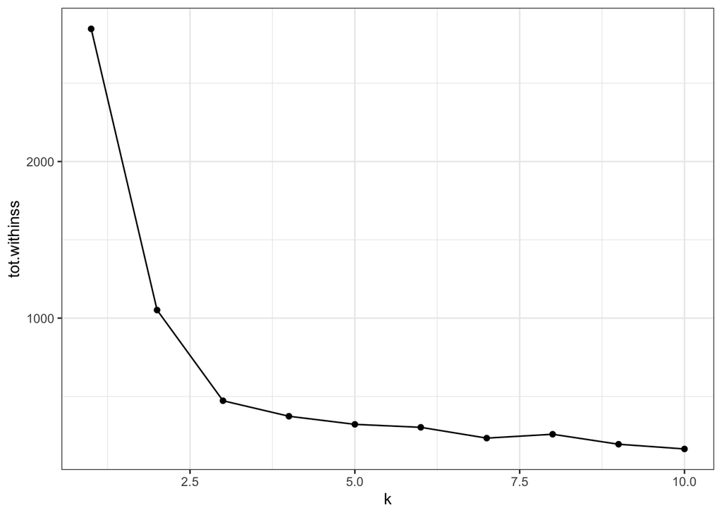

```r
ggplot(clusterings, aes(k, tot.withinss)) +
  geom_line() +
  geom_point() + theme_bw()
```

Now we can cluster. Let’s go with 4 clusters.

```r
cust_clust = kmeans(customers_scaled, centers = 4) #run k-means clustering with k = 4
cust_clust #view results
```

```
## K-means clustering with 4 clusters of sizes 131, 3, 10, 296
##
## Cluster means:
##      Channel      Region       Fresh      Dairy    Grocery       Frozen
## 1  1.4470045  0.10690343 -0.29218794  0.4286373  0.6330682 -0.329983553
## 2 -0.6895122  0.15948501  3.84044484  3.2957757  0.9852919  7.204892918
## 3  1.4470045 -0.05577083  0.31347349  3.9174467  4.2707490 -0.003570131
## 4 -0.6822942 -0.04704424  0.07979916 -0.3554503 -0.4344436  0.073138067
##   Detergents_Paper        Deli
## 1        0.6495639  0.04416479
## 2       -0.1527927  6.79967230
## 3        4.6129149  0.50279301
## 4       -0.4417690 -0.10544775
##
## Clustering vector:
##   [1] 1 1 1 4 1 1 1 1 4 1 1 1 1 1 1 4 1 4 1 4 1 4 4 1 1 1 4 4 1 4 4 4 4 4 4 1 4
##  [38] 1 1 4 4 4 1 1 1 1 1 3 1 1 4 4 1 1 4 4 3 1 4 4 1 3 1 1 4 3 4 1 4 4 4 4 4 1
##  [75] 1 4 4 1 4 4 4 1 1 4 1 3 3 4 4 4 4 4 3 4 1 4 1 4 4 4 1 1 1 4 4 4 1 1 1 1 4
## [112] 1 4 4 4 4 4 4 4 4 4 4 4 1 4 4 4 1 4 4 4 4 4 4 4 4 4 4 4 4 4 4 4 4 4 1 4 4
## [149] 4 4 4 4 4 4 4 1 1 4 1 1 1 4 4 1 1 1 1 4 4 4 1 1 4 1 4 1 4 4 4 4 4 2 4 2 4
## [186] 4 4 4 1 1 4 4 4 1 4 4 4 1 4 4 1 1 4 4 4 1 4 1 4 1 4 3 4 4 1 4 1 4 1 4 4 4
## [223] 4 1 4 4 1 4 4 4 1 4 4 4 4 4 4 4 4 4 4 4 4 4 4 1 4 4 4 4 4 3 4 4 4 4 4 4 4
## [260] 4 4 4 4 4 1 4 1 4 1 4 4 4 4 4 4 4 4 4 4 1 4 1 4 4 4 4 4 4 4 4 4 4 4 1 4 1
## [297] 4 1 1 4 1 1 1 1 1 1 1 4 4 1 4 4 1 4 4 1 4 4 4 1 4 4 4 4 4 2 4 4 4 4 4 1 4
## [334] 3 4 1 4 4 4 4 1 1 4 1 4 4 1 1 4 1 4 1 4 1 4 4 4 1 4 4 4 4 4 4 4 1 4 4 4 4
## [371] 1 4 4 1 4 4 1 4 4 1 4 4 4 4 4 4 4 4 4 4 4 4 4 4 4 4 1 4 4 4 4 4 4 4 4 4 4
## [408] 1 1 4 4 4 4 4 4 1 1 4 1 4 4 1 4 1 1 4 4 4 4 4 4 4 4 4 4 4 4 1 4 4
##
## Within cluster sum of squares by cluster:
## [1]  437.3645  215.6517  160.2905 1020.2318
##  (between_SS / total_SS =  47.8 %)
##
## Available components:
##
## [1] "cluster"      "centers"      "totss"        "withinss"     "tot.withinss"
## [6] "betweenss"    "size"         "iter"         "ifault"
```

Use augment to append the clusters to the data (append to the non-scaled data)

```r
customers = augment(cust_clust, customers)
head(customers)
```

```
## # A tibble: 6 × 9
##   Channel Region Fresh Dairy Grocery Frozen Detergents_Paper  Deli .cluster
##     <dbl>  <dbl> <dbl> <dbl>   <dbl>  <dbl>            <dbl> <dbl> <fct>
## 1       2      3 12669  9656    7561    214             2674  1338 1
## 2       2      3  7057  9810    9568   1762             3293  1776 1
## 3       2      3  6353  8808    7684   2405             3516  7844 1
## 4       1      3 13265  1196    4221   6404              507  1788 4
## 5       2      3 22615  5410    7198   3915             1777  5185 1
## 6       2      3  9413  8259    5126    666             1795  1451 1
```

We can then explore the data looking for commonalities within the clusters. Note: Visualization would take place on the non-scaled data.